# Divvy Exercise full Year Analysis

For this case Study written by Kevin Hartman [link here](https://artscience.blog/home/divvy-dataviz-case-study). In this case study we are using Rstudio to consolidate Divvy dataset into a single data frame and them conduct different analysis to answer our stakeholder questions.

### Install required packages

- tidyverse for data import and wrangling
- lubridate for date functions
- ggplot for visualization

```r
install.packages("tidyverse")
install.packages("lubridate")
install.packages("ggplot2")
```

### Loading the libraries

```r
library(tidyverse)
library(lubridate)
library(ggplot2)
```

The working directory is hosted in my laptop, data set downloaded from fictional public data.

## Colleting Data

Uploading Divvy datasets (csv files)

```r
q2_2019 <- read.csv("Divvy_Trips_2019_Q2.csv")
q3_2019 <- read.csv("Divvy_Trips_2019_Q3.csv")
q4_2019 <- read.csv("Divvy_Trips_2019_Q4.csv")
q1_2020 <- read.csv("Divvy_Trips_2020_Q1.csv")
```

## Wrangle Data and combine into a single file

I will use the colnames function to compare column names for each files, in order to join them later. They need to match perfectly.

```r
colnames(q4_2019)
```

```
 [1] "trip_id"           "start_time"        "end_time"          "bikeid"            "tripduration"      "from_station_id"   "from_station_name"
 [8] "to_station_id"     "to_station_name"   "usertype"          "gender"            "birthyear"
```

```r
colnames(q3_2019)
```

```
 [1] "trip_id"           "start_time"        "end_time"          "bikeid"            "tripduration"      "from_station_id"   "from_station_name"
 [8] "to_station_id"     "to_station_name"   "usertype"          "gender"            "birthyear"
```

```r
colnames(q2_2019)
```

```
 [1] "X01...Rental.Details.Rental.ID"                    "X01...Rental.Details.Local.Start.Time"
 [3] "X01...Rental.Details.Local.End.Time"               "X01...Rental.Details.Bike.ID"
 [5] "X01...Rental.Details.Duration.In.Seconds.Uncapped" "X03...Rental.Start.Station.ID"
 [7] "X03...Rental.Start.Station.Name"                   "X02...Rental.End.Station.ID"
 [9] "X02...Rental.End.Station.Name"                     "User.Type"
[11] "Member.Gender"                                     "X05...Member.Details.Member.Birthday.Year"
```

```r
colnames(q1_2020)
```

```
 [1] "ride_id"            "rideable_type"      "started_at"         "ended_at"           "start_station_name" "start_station_id"
 [7] "end_station_name"   "end_station_id"     "start_lat"          "start_lng"          "end_lat"            "end_lng"
[13] "member_casual"
```

For consistency I will rename columns to match the q1_2020.

```r
(q4_2019 <- rename(q4_2019
                   ,ride_id = trip_id
                   ,rideable_type = bikeid
                   ,started_at = start_time
                   ,ended_at = end_time
                   ,start_station_name = from_station_name
                   ,start_station_id = from_station_id
                   ,end_station_name = to_station_name
                   ,end_station_id = to_station_id
                   ,member_casual = usertype))
```

| ride_id | started_at | ended_at | rideable_type | tripduration | start_station_id | start_station_name | end_station_id | end_station_name | member_casual | gender | birthyear |
| --- | --- | --- | --- | --- | --- | --- | --- | --- | --- | --- | --- |
| 25223640 | 2019-10-01 00:01:39 | 2019-10-01 00:17:20 | 2215 | 940.0 | 20 | Sheffield Ave & Kingsbury St | 309 | Leavitt St & Armitage Ave | Subscriber | Male | 1987 |
| 25223641 | 2019-10-01 00:02:16 | 2019-10-01 00:06:34 | 6328 | 258.0 | 19 | Throop (Loomis) St & Taylor St | 241 | Morgan St & Polk St | Subscriber | Male | 1998 |
| 25223642 | 2019-10-01 00:04:32 | 2019-10-01 00:18:43 | 3003 | 850.0 | 84 | Milwaukee Ave & Grand Ave | 199 | Wabash Ave & Grand Ave | Subscriber | Female | 1991 |
| 25223643 | 2019-10-01 00:04:32 | 2019-10-01 00:43:43 | 3275 | 2,350.0 | 313 | Lakeview Ave & Fullerton Pkwy | 290 | Kedzie Ave & Palmer Ct | Subscriber | Male | 1990 |
| 25223644 | 2019-10-01 00:04:34 | 2019-10-01 00:35:42 | 5294 | 1,867.0 | 210 | Ashland Ave & Division St | 382 | Western Ave & Congress Pkwy | Subscriber | Male | 1987 |
| 25223645 | 2019-10-01 00:04:38 | 2019-10-01 00:10:51 | 1891 | 373.0 | 156 | Clark St & Wellington Ave | 226 | Racine Ave & Belmont Ave | Subscriber | Female | 1994 |
| 25223646 | 2019-10-01 00:04:52 | 2019-10-01 00:22:45 | 1061 | 1,072.0 | 84 | Milwaukee Ave & Grand Ave | 142 | McClurg Ct & Erie St | Subscriber | Female | 1991 |
| 25223647 | 2019-10-01 00:04:57 | 2019-10-01 00:29:16 | 1274 | 1,458.0 | 156 | Clark St & Wellington Ave | 463 | Clark St & Berwyn Ave | Subscriber | Male | 1995 |
| 25223648 | 2019-10-01 00:05:20 | 2019-10-01 00:29:18 | 6011 | 1,437.0 | 156 | Clark St & Wellington Ave | 463 | Clark St & Berwyn Ave | Subscriber | Female | 1993 |
| 25223649 | 2019-10-01 00:05:20 | 2019-10-01 02:23:46 | 2957 | 8,306.0 | 336 | Cottage Grove Ave & 47th St | 336 | Cottage Grove Ave & 47th St | Customer |  | NA |

[output cut: 990 more lines]

```r
(q3_2019 <- rename(q3_2019
                   ,ride_id = trip_id
                   ,rideable_type = bikeid
                   ,started_at = start_time
                   ,ended_at = end_time
                   ,start_station_name = from_station_name
                   ,start_station_id = from_station_id
                   ,end_station_name = to_station_name
                   ,end_station_id = to_station_id
                   ,member_casual = usertype))
```

| ride_id | started_at | ended_at | rideable_type | tripduration | start_station_id | start_station_name | end_station_id | end_station_name | member_casual | gender | birthyear |
| --- | --- | --- | --- | --- | --- | --- | --- | --- | --- | --- | --- |
| 23479388 | 2019-07-01 00:00:27 | 2019-07-01 00:20:41 | 3591 | 1,214.0 | 117 | Wilton Ave & Belmont Ave | 497 | Kimball Ave & Belmont Ave | Subscriber | Male | 1992 |
| 23479389 | 2019-07-01 00:01:16 | 2019-07-01 00:18:44 | 5353 | 1,048.0 | 381 | Western Ave & Monroe St | 203 | Western Ave & 21st St | Customer |  | NA |
| 23479390 | 2019-07-01 00:01:48 | 2019-07-01 00:27:42 | 6180 | 1,554.0 | 313 | Lakeview Ave & Fullerton Pkwy | 144 | Larrabee St & Webster Ave | Customer |  | NA |
| 23479391 | 2019-07-01 00:02:07 | 2019-07-01 00:27:10 | 5540 | 1,503.0 | 313 | Lakeview Ave & Fullerton Pkwy | 144 | Larrabee St & Webster Ave | Customer |  | NA |
| 23479392 | 2019-07-01 00:02:13 | 2019-07-01 00:22:26 | 6014 | 1,213.0 | 168 | Michigan Ave & 14th St | 62 | McCormick Place | Customer |  | NA |
| 23479393 | 2019-07-01 00:02:21 | 2019-07-01 00:07:31 | 4941 | 310.0 | 300 | Broadway & Barry Ave | 232 | Pine Grove Ave & Waveland Ave | Subscriber | Male | 1990 |
| 23479394 | 2019-07-01 00:02:24 | 2019-07-01 00:23:12 | 3770 | 1,248.0 | 168 | Michigan Ave & 14th St | 62 | McCormick Place | Customer |  | NA |
| 23479395 | 2019-07-01 00:02:26 | 2019-07-01 00:28:16 | 5442 | 1,550.0 | 313 | Lakeview Ave & Fullerton Pkwy | 144 | Larrabee St & Webster Ave | Customer |  | NA |
| 23479396 | 2019-07-01 00:02:34 | 2019-07-01 00:28:57 | 2957 | 1,583.0 | 43 | Michigan Ave & Washington St | 195 | Columbus Dr & Randolph St | Customer |  | NA |
| 23479397 | 2019-07-01 00:02:45 | 2019-07-01 00:29:14 | 6091 | 1,589.0 | 43 | Michigan Ave & Washington St | 195 | Columbus Dr & Randolph St | Customer |  | NA |

[output cut: 990 more lines]

```r
(q2_2019 <- rename(q2_2019
                   ,ride_id = "X01...Rental.Details.Rental.ID"
                   ,rideable_type = "X01...Rental.Details.Bike.ID"
                   ,started_at = "X01...Rental.Details.Local.Start.Time"
                   ,ended_at = "X01...Rental.Details.Local.End.Time"
                   ,start_station_name = "X03...Rental.Start.Station.Name"
                   ,start_station_id = "X03...Rental.Start.Station.ID"
                   ,end_station_name = "X02...Rental.End.Station.Name"
                   ,end_station_id = "X02...Rental.End.Station.ID"
                   ,member_casual = "User.Type"))
```

| ride_id | started_at | ended_at | rideable_type | X01...Rental.Details.Duration.In.Seconds.Uncapped | start_station_id | start_station_name | end_station_id | end_station_name | member_casual | Member.Gender | X05...Member.Details.Member.Birthday.Year |
| --- | --- | --- | --- | --- | --- | --- | --- | --- | --- | --- | --- |
| 22178529 | 2019-04-01 00:02:22 | 2019-04-01 00:09:48 | 6251 | 446.0 | 81 | Daley Center Plaza | 56 | Desplaines St & Kinzie St | Subscriber | Male | 1975 |
| 22178530 | 2019-04-01 00:03:02 | 2019-04-01 00:20:30 | 6226 | 1,048.0 | 317 | Wood St & Taylor St | 59 | Wabash Ave & Roosevelt Rd | Subscriber | Female | 1984 |
| 22178531 | 2019-04-01 00:11:07 | 2019-04-01 00:15:19 | 5649 | 252.0 | 283 | LaSalle St & Jackson Blvd | 174 | Canal St & Madison St | Subscriber | Male | 1990 |
| 22178532 | 2019-04-01 00:13:01 | 2019-04-01 00:18:58 | 4151 | 357.0 | 26 | McClurg Ct & Illinois St | 133 | Kingsbury St & Kinzie St | Subscriber | Male | 1993 |
| 22178533 | 2019-04-01 00:19:26 | 2019-04-01 00:36:13 | 3270 | 1,007.0 | 202 | Halsted St & 18th St | 129 | Blue Island Ave & 18th St | Subscriber | Male | 1992 |
| 22178534 | 2019-04-01 00:19:39 | 2019-04-01 00:23:56 | 3123 | 257.0 | 420 | Ellis Ave & 55th St | 426 | Ellis Ave & 60th St | Subscriber | Male | 1999 |
| 22178535 | 2019-04-01 00:26:33 | 2019-04-01 00:35:41 | 6418 | 548.0 | 503 | Drake Ave & Fullerton Ave | 500 | Central Park Ave & Elbridge Ave | Subscriber | Male | 1969 |
| 22178536 | 2019-04-01 00:29:48 | 2019-04-01 00:36:11 | 4513 | 383.0 | 260 | Kedzie Ave & Milwaukee Ave | 499 | Kosciuszko Park | Subscriber | Male | 1991 |
| 22178537 | 2019-04-01 00:32:07 | 2019-04-01 01:07:44 | 3280 | 2,137.0 | 211 | St. Clair St & Erie St | 211 | St. Clair St & Erie St | Customer |  | NA |
| 22178538 | 2019-04-01 00:32:19 | 2019-04-01 01:07:39 | 5534 | 2,120.0 | 211 | St. Clair St & Erie St | 211 | St. Clair St & Erie St | Customer |  | NA |

[output cut: 990 more lines]

For incongruencies in the dataframe you have to inspect

```r
str(q1_2020)
```

```
'data.frame':   426887 obs. of  13 variables:
 $ ride_id           : chr  "EACB19130B0CDA4A" "8FED874C809DC021" "789F3C21E472CA96" "C9A388DAC6ABF313" ...
 $ rideable_type     : chr  "docked_bike" "docked_bike" "docked_bike" "docked_bike" ...
 $ started_at        : chr  "2020-01-21 20:06:59" "2020-01-30 14:22:39" "2020-01-09 19:29:26" "2020-01-06 16:17:07" ...
 $ ended_at          : chr  "2020-01-21 20:14:30" "2020-01-30 14:26:22" "2020-01-09 19:32:17" "2020-01-06 16:25:56" ...
 $ start_station_name: chr  "Western Ave & Leland Ave" "Clark St & Montrose Ave" "Broadway & Belmont Ave" "Clark St & Randolph St" ...
 $ start_station_id  : int  239 234 296 51 66 212 96 96 212 38 ...
 $ end_station_name  : chr  "Clark St & Leland Ave" "Southport Ave & Irving Park Rd" "Wilton Ave & Belmont Ave" "Fairbanks Ct & Grand Ave" ...
 $ end_station_id    : int  326 318 117 24 212 96 212 212 96 100 ...
 $ start_lat         : num  42 42 41.9 41.9 41.9 ...
 $ start_lng         : num  -87.7 -87.7 -87.6 -87.6 -87.6 ...
 $ end_lat           : num  42 42 41.9 41.9 41.9 ...
 $ end_lng           : num  -87.7 -87.7 -87.7 -87.6 -87.6 ...
 $ member_casual     : chr  "member" "member" "member" "member" ...
```

```r
str(q2_2019)
```

```
'data.frame':   1108163 obs. of  12 variables:
 $ ride_id                                          : int  22178529 22178530 22178531 22178532 22178533 22178534 22178535 22178536 22178537 22178538 ...
 $ started_at                                       : chr  "2019-04-01 00:02:22" "2019-04-01 00:03:02" "2019-04-01 00:11:07" "2019-04-01 00:13:01" ...
 $ ended_at                                         : chr  "2019-04-01 00:09:48" "2019-04-01 00:20:30" "2019-04-01 00:15:19" "2019-04-01 00:18:58" ...
 $ rideable_type                                    : int  6251 6226 5649 4151 3270 3123 6418 4513 3280 5534 ...
 $ X01...Rental.Details.Duration.In.Seconds.Uncapped: chr  "446.0" "1,048.0" "252.0" "357.0" ...
 $ start_station_id                                 : int  81 317 283 26 202 420 503 260 211 211 ...
 $ start_station_name                               : chr  "Daley Center Plaza" "Wood St & Taylor St" "LaSalle St & Jackson Blvd" "McClurg Ct & Illinois St" ...
 $ end_station_id                                   : int  56 59 174 133 129 426 500 499 211 211 ...
 $ end_station_name                                 : chr  "Desplaines St & Kinzie St" "Wabash Ave & Roosevelt Rd" "Canal St & Madison St" "Kingsbury St & Kinzie St" ...
 $ member_casual                                    : chr  "Subscriber" "Subscriber" "Subscriber" "Subscriber" ...
 $ Member.Gender                                    : chr  "Male" "Female" "Male" "Male" ...
 $ X05...Member.Details.Member.Birthday.Year        : int  1975 1984 1990 1993 1992 1999 1969 1991 NA NA ...
```

```r
str(q3_2019)
```

```
'data.frame':   1640718 obs. of  12 variables:
 $ ride_id           : int  23479388 23479389 23479390 23479391 23479392 23479393 23479394 23479395 23479396 23479397 ...
 $ started_at        : chr  "2019-07-01 00:00:27" "2019-07-01 00:01:16" "2019-07-01 00:01:48" "2019-07-01 00:02:07" ...
 $ ended_at          : chr  "2019-07-01 00:20:41" "2019-07-01 00:18:44" "2019-07-01 00:27:42" "2019-07-01 00:27:10" ...
 $ rideable_type     : int  3591 5353 6180 5540 6014 4941 3770 5442 2957 6091 ...
 $ tripduration      : chr  "1,214.0" "1,048.0" "1,554.0" "1,503.0" ...
 $ start_station_id  : int  117 381 313 313 168 300 168 313 43 43 ...
 $ start_station_name: chr  "Wilton Ave & Belmont Ave" "Western Ave & Monroe St" "Lakeview Ave & Fullerton Pkwy" "Lakeview Ave & Fullerton Pkwy" ...
 $ end_station_id    : int  497 203 144 144 62 232 62 144 195 195 ...
 $ end_station_name  : chr  "Kimball Ave & Belmont Ave" "Western Ave & 21st St" "Larrabee St & Webster Ave" "Larrabee St & Webster Ave" ...
 $ member_casual     : chr  "Subscriber" "Customer" "Customer" "Customer" ...
 $ gender            : chr  "Male" "" "" "" ...
 $ birthyear         : int  1992 NA NA NA NA 1990 NA NA NA NA ...
```

```r
str(q4_2019)
```

```
'data.frame':   704054 obs. of  12 variables:
 $ ride_id           : int  25223640 25223641 25223642 25223643 25223644 25223645 25223646 25223647 25223648 25223649 ...
 $ started_at        : chr  "2019-10-01 00:01:39" "2019-10-01 00:02:16" "2019-10-01 00:04:32" "2019-10-01 00:04:32" ...
 $ ended_at          : chr  "2019-10-01 00:17:20" "2019-10-01 00:06:34" "2019-10-01 00:18:43" "2019-10-01 00:43:43" ...
 $ rideable_type     : int  2215 6328 3003 3275 5294 1891 1061 1274 6011 2957 ...
 $ tripduration      : chr  "940.0" "258.0" "850.0" "2,350.0" ...
 $ start_station_id  : int  20 19 84 313 210 156 84 156 156 336 ...
 $ start_station_name: chr  "Sheffield Ave & Kingsbury St" "Throop (Loomis) St & Taylor St" "Milwaukee Ave & Grand Ave" "Lakeview Ave & Fullerton Pkwy" ...
 $ end_station_id    : int  309 241 199 290 382 226 142 463 463 336 ...
 $ end_station_name  : chr  "Leavitt St & Armitage Ave" "Morgan St & Polk St" "Wabash Ave & Grand Ave" "Kedzie Ave & Palmer Ct" ...
 $ member_casual     : chr  "Subscriber" "Subscriber" "Subscriber" "Subscriber" ...
 $ gender            : chr  "Male" "Male" "Female" "Male" ...
 $ birthyear         : int  1987 1998 1991 1990 1987 1994 1991 1995 1993 NA ...
```

Now that you checked for incongruencies, the next step is to mutate into character so that they can stack correctly.

```r
q4_2019 <- mutate(q4_2019, ride_id = as.character("ride_id")
                  ,rideable_type = as.character("rideable_type"))
q3_2019 <- mutate(q3_2019, ride_id = as.character("ride_id")
                  ,rideable_type = as.character("rideable_type"))
q2_2019 <- mutate(q2_2019, ride_id = as.character("ride_id")
                  ,rideable_type = as.character("rideable_type"))
```

For the next step we´ll be stacking data frames into one big data frame using bind_rows.

```r
all_trips <- bind_rows(q2_2019, q3_2019, q4_2019, q1_2020)
```

Remove lat, lng, birthyear, and gender fields as this data was dropped at the beginning of 2020.

```r
all_trips <- all_trips %>%
    select(-c(start_lat, start_lng, end_lat, end_lng, birthyear, gender, "X01...Rental.Details.Duration.In.Seconds.Uncapped", "X05...Member.Details.Member.Birthday.Year", "Member.Gender", "tripduration"))
```

To View the data frame set use View().

```r
View(all_trips)
```

## Cleanup and add Data to prepare for analysis

Inspecting the data that has been created:

- List of column names

```r
colnames(all_trips)
```

```
[1] "ride_id"            "started_at"         "ended_at"           "rideable_type"      "start_station_id"   "start_station_name"
[7] "end_station_id"     "end_station_name"   "member_casual"
```

- How many rows are in data frame?

```r
nrow(all_trips)
```

```
[1] 3879822
```

- Dimensions of the data frame?

```r
dim(all_trips)
```

```
[1] 3879822       9
```

- See the first 6 rows of data frame. Also another function for the last 6.

```r
head(all_trips)
```

|  | ride_id | started_at | ended_at | rideable_type | start_station_id | start_station_name | end_station_id | end_station_name | member_casual |
| --- | --- | --- | --- | --- | --- | --- | --- | --- | --- |
| 1 | ride_id | 2019-04-01 00:02:22 | 2019-04-01 00:09:48 | rideable_type | 81 | Daley Center Plaza | 56 | Desplaines St & Kinzie St | Subscriber |
| 2 | ride_id | 2019-04-01 00:03:02 | 2019-04-01 00:20:30 | rideable_type | 317 | Wood St & Taylor St | 59 | Wabash Ave & Roosevelt Rd | Subscriber |
| 3 | ride_id | 2019-04-01 00:11:07 | 2019-04-01 00:15:19 | rideable_type | 283 | LaSalle St & Jackson Blvd | 174 | Canal St & Madison St | Subscriber |
| 4 | ride_id | 2019-04-01 00:13:01 | 2019-04-01 00:18:58 | rideable_type | 26 | McClurg Ct & Illinois St | 133 | Kingsbury St & Kinzie St | Subscriber |
| 5 | ride_id | 2019-04-01 00:19:26 | 2019-04-01 00:36:13 | rideable_type | 202 | Halsted St & 18th St | 129 | Blue Island Ave & 18th St | Subscriber |
| 6 | ride_id | 2019-04-01 00:19:39 | 2019-04-01 00:23:56 | rideable_type | 420 | Ellis Ave & 55th St | 426 | Ellis Ave & 60th St | Subscriber |

```r
tail(all_trips)
```

|  | ride_id | started_at | ended_at | rideable_type | start_station_id | start_station_name | end_station_id | end_station_name | member_casual |
| --- | --- | --- | --- | --- | --- | --- | --- | --- | --- |
| 3879817 | 6F4D221BDDFD943F | 2020-03-10 10:40:27 | 2020-03-10 10:40:29 | docked_bike | 675 | HQ QR | 675 | HQ QR | casual |
| 3879818 | ADDAA33CEBCAE733 | 2020-03-10 10:40:06 | 2020-03-10 10:40:07 | docked_bike | 675 | HQ QR | 675 | HQ QR | casual |
| 3879819 | 82B10FA3994BC66A | 2020-03-07 15:25:55 | 2020-03-07 16:14:03 | docked_bike | 161 | Rush St & Superior St | 240 | Sheridan Rd & Irving Park Rd | member |
| 3879820 | AA0D5AAA0B59C8AA | 2020-03-01 13:12:38 | 2020-03-01 13:38:29 | docked_bike | 141 | Clark St & Lincoln Ave | 210 | Ashland Ave & Division St | casual |
| 3879821 | 3296360A7BC20FB8 | 2020-03-07 18:02:45 | 2020-03-07 18:13:18 | docked_bike | 672 | Franklin St & Illinois St | 264 | Stetson Ave & South Water St | member |
| 3879822 | 064EC7698E4FF9B3 | 2020-03-08 13:03:57 | 2020-03-08 13:32:27 | docked_bike | 110 | Dearborn St & Erie St | 85 | Michigan Ave & Oak St | casual |

- See list of columns and data types (numeric, character, etc)

```r
str(all_trips)
```

```
'data.frame':   3879822 obs. of  9 variables:
 $ ride_id           : chr  "ride_id" "ride_id" "ride_id" "ride_id" ...
 $ started_at        : chr  "2019-04-01 00:02:22" "2019-04-01 00:03:02" "2019-04-01 00:11:07" "2019-04-01 00:13:01" ...
 $ ended_at          : chr  "2019-04-01 00:09:48" "2019-04-01 00:20:30" "2019-04-01 00:15:19" "2019-04-01 00:18:58" ...
 $ rideable_type     : chr  "rideable_type" "rideable_type" "rideable_type" "rideable_type" ...
 $ start_station_id  : int  81 317 283 26 202 420 503 260 211 211 ...
 $ start_station_name: chr  "Daley Center Plaza" "Wood St & Taylor St" "LaSalle St & Jackson Blvd" "McClurg Ct & Illinois St" ...
 $ end_station_id    : int  56 59 174 133 129 426 500 499 211 211 ...
 $ end_station_name  : chr  "Desplaines St & Kinzie St" "Wabash Ave & Roosevelt Rd" "Canal St & Madison St" "Kingsbury St & Kinzie St" ...
 $ member_casual     : chr  "Subscriber" "Subscriber" "Subscriber" "Subscriber" ...
```

- Statistical summary of data:

```r
summary(all_trips)
```

```
   ride_id           started_at          ended_at         rideable_type      start_station_id start_station_name end_station_id
 Length:3879822     Length:3879822     Length:3879822     Length:3879822     Min.   :  1.0    Length:3879822     Min.   :  1.0
 Class :character   Class :character   Class :character   Class :character   1st Qu.: 77.0    Class :character   1st Qu.: 77.0
 Mode  :character   Mode  :character   Mode  :character   Mode  :character   Median :174.0    Mode  :character   Median :174.0
                                                                             Mean   :202.9                       Mean   :203.8
                                                                             3rd Qu.:291.0                       3rd Qu.:291.0
                                                                             Max.   :675.0                       Max.   :675.0
                                                                                                                 NA's   :1
 end_station_name   member_casual
 Length:3879822     Length:3879822
 Class :character   Class :character
 Mode  :character   Mode  :character
```

## Few problems that you need to address first

1. In the “member_casual” column, there are two names for members (“member” and ““Subscriber”) and two names for casual riders (“Customer” and “casual”). We will need to consolidate that from four to two labels.
2. The data can only be aggregated at the ride-level, which is too granular. We will want to add some additional columns of data – such as day, month, year – that provide additional opportunities to aggregate the data.
3. We will want to add a calculated field for length of ride since the 2020Q1 data did not have the “tripduration” column. We will add “ride_length” to the entire dataframe for consistency.
4. There are some rides where tripduration shows up as negative, including several hundred rides where Divvy took bikes out of circulation for Quality Control reasons. We will want to delete those rides.

In the “member_casual” column, replace “Subscriber” with “member” and “Customer” with “casual”.

Before 2020, Divvy used different labels for these two types of riders … we will want to make our dataframe consistent with their current nomenclature.

N.B.: “Level” is a special property of a column that is retained even if a subset does not contain any values from a specific level.

- How many observations fall under each usertype?

```r
table(all_trips$member_casual)
```

```
    casual   Customer     member Subscriber
     48480     857474     378407    2595461
```

- We will go with the 2020 labels in order to reassign desired values.

```r
all_trips <- all_trips %>%
  mutate(member_casual = recode(member_casual
                                ,"Subscriber" = "member"
                                ,"Customer" = "casual"))
```

Check to make sure the proper number of observations were reassigned.

```r
table(all_trips$member_casual)
```

```
 casual  member
 905954 2973868
```

This will allow us to aggregate ride data for each month, day, or year. Before those operations were completed, we could only aggregate at the ride level.

For future references on date formats in R [here](https://www.statmethods.net/input/dates.html)

- Just remember that the default format is yyyy-mm-dd.

```r
all_trips$date <-as.Date(all_trips$started_at)
all_trips$month <-format(as.Date(all_trips$date), "%m")
all_trips$day <- format(as.Date(all_trips$date), "%d")
all_trips$year <-format(as.Date(all_trips$date), "%Y")
all_trips$day_of_week <-format(as.Date(all_trips$date), "%A")
```

Add a “ride_length” calculation to all_trips (in seconds)[Click here for more difftime](https://stat.ethz.ch/R-manual/R-devel/library/base/html/difftime.html)

```r
all_trips$ride_length <- difftime(all_trips$ended_at,all_trips$started_at)
```

- Inspect the structure of the columns

```r
str(all_trips)
```

```
'data.frame':   3879822 obs. of  15 variables:
 $ ride_id           : chr  "ride_id" "ride_id" "ride_id" "ride_id" ...
 $ started_at        : chr  "2019-04-01 00:02:22" "2019-04-01 00:03:02" "2019-04-01 00:11:07" "2019-04-01 00:13:01" ...
 $ ended_at          : chr  "2019-04-01 00:09:48" "2019-04-01 00:20:30" "2019-04-01 00:15:19" "2019-04-01 00:18:58" ...
 $ rideable_type     : chr  "rideable_type" "rideable_type" "rideable_type" "rideable_type" ...
 $ start_station_id  : int  81 317 283 26 202 420 503 260 211 211 ...
 $ start_station_name: chr  "Daley Center Plaza" "Wood St & Taylor St" "LaSalle St & Jackson Blvd" "McClurg Ct & Illinois St" ...
 $ end_station_id    : int  56 59 174 133 129 426 500 499 211 211 ...
 $ end_station_name  : chr  "Desplaines St & Kinzie St" "Wabash Ave & Roosevelt Rd" "Canal St & Madison St" "Kingsbury St & Kinzie St" ...
 $ member_casual     : chr  "member" "member" "member" "member" ...
 $ date              : Date, format: "2019-04-01" "2019-04-01" "2019-04-01" "2019-04-01" ...
 $ month             : chr  "04" "04" "04" "04" ...
 $ day               : chr  "01" "01" "01" "01" ...
 $ year              : chr  "2019" "2019" "2019" "2019" ...
 $ day_of_week       : chr  "lunes" "lunes" "lunes" "lunes" ...
 $ ride_length       : 'difftime' num  446 1048 252 357 ...
  ..- attr(*, "units")= chr "secs"
```

```r
is.factor(all_trips$ride_length)
```

```
[1] FALSE
```

```r
all_trips$ride_length <- as.numeric(as.character(all_trips$ride_length))
```

```r
is.numeric(all_trips$ride_length)
```

```
[1] TRUE
```

## Removing “bad” data

The dataframe includes a few hundred entries when bikes were taken out of docks and checked for quality by Divvy or ride_length was negative.

We will create a new version of the dataframe (v2) since data is being removed. [For more delete or drop rows in r, click here](https://www.datasciencemadesimple.com/delete-or-drop-rows-in-r-with-conditions-2/)

```r
all_trips_v2 <- all_trips[!(all_trips$start_station_name == "HQ QR" | all_trips$ride_length<0),]
```

# Conduct descriptive analysis

Descriptive analysis on ride_length (all figures in seconds)

- straight average (total ride length / rides)

```r
mean(all_trips_v2$ride_length)
```

```
[1] 1479.139
```

- midpoint number in the ascending array of ride lengths

```r
median(all_trips_v2$ride_length)
```

```
[1] 712
```

- Longest ride

```r
max(all_trips_v2$ride_length)
```

```
[1] 9387024
```

- Shortest ride

```r
min(all_trips_v2$ride_length)
```

```
[1] 1
```

- You can condense the four lines above to one line using summary() on the specific attribute.

```r
summary(all_trips_v2$ride_length)
```

```
   Min. 1st Qu.  Median    Mean 3rd Qu.    Max.
      1     412     712    1479    1289 9387024
```

- Compare members and casual users

```r
aggregate(all_trips_v2$ride_length ~ all_trips_v2$member_casual, FUN = mean)
```

| all_trips_v2$member_casual | all_trips_v2$ride_length |
| --- | --- |
| casual | 3552.7502 |
| member | 850.0662 |

```r
aggregate(all_trips_v2$ride_length ~ all_trips_v2$member_casual, FUN = median)
```

| all_trips_v2$member_casual | all_trips_v2$ride_length |
| --- | --- |
| casual | 1546 |
| member | 589 |

```r
aggregate(all_trips_v2$ride_length ~ all_trips_v2$member_casual, FUN = max)
```

| all_trips_v2$member_casual | all_trips_v2$ride_length |
| --- | --- |
| casual | 9387024 |
| member | 9056634 |

```r
aggregate(all_trips_v2$ride_length ~ all_trips_v2$member_casual, FUN = min)
```

| all_trips_v2$member_casual | all_trips_v2$ride_length |
| --- | --- |
| casual | 2 |
| member | 1 |

To see the average ride time by each day for members vs casual users

```r
aggregate(all_trips_v2$ride_length ~ all_trips_v2$member_casual + all_trips_v2$day_of_week, FUN = mean)
```

| all_trips_v2$member_casual | all_trips_v2$day_of_week | all_trips_v2$ride_length |
| --- | --- | --- |
| casual | domingo | 3581.4054 |
| member | domingo | 919.9746 |
| casual | jueves | 3682.9847 |
| member | jueves | 823.9278 |
| casual | lunes | 3372.2869 |
| member | lunes | 842.5726 |
| casual | martes | 3596.3599 |
| member | martes | 826.1427 |
| casual | miércoles | 3718.6619 |
| member | miércoles | 823.9996 |

[output cut: 4 more lines]

Notice that the days of the week are out of order

```r
all_trips_v2$day_of_week <- ordered(all_trips_v2$day_of_week, levels = c("domingo", "lunes", "martes", "miercoles", "jueves", "viernes", "sabado"))
```

Now, let’s run the average ride time by each for members vs casual users

```r
aggregate(all_trips_v2$ride_length ~ all_trips_v2$member_casual + all_trips_v2$day_of_week, FUN = mean)
```

| all_trips_v2$member_casual | all_trips_v2$day_of_week | all_trips_v2$ride_length |
| --- | --- | --- |
| casual | domingo | 3581.4054 |
| member | domingo | 919.9746 |
| casual | lunes | 3372.2869 |
| member | lunes | 842.5726 |
| casual | martes | 3596.3599 |
| member | martes | 826.1427 |
| casual | jueves | 3682.9847 |
| member | jueves | 823.9278 |
| casual | viernes | 3773.8351 |
| member | viernes | 824.5305 |

Now, let’s analyze ridership data by type and weekday

- mutate, creates weekday field using wday().
- group_by, groups by usertype and weekday.
- summarise, calculates the number of rides and average duration.
- average_duration, calculates the average duration.
- arrange, sorts.

```r
all_trips_v2 %>%
  mutate(weekday = wday(started_at, label = TRUE)) %>%
  group_by(member_casual, weekday) %>%
  summarise(number_of_rides = n(), average_duration = mean(ride_length)) %>%
  arrange(member_casual, weekday)
```

| member_casual | weekday | number_of_rides | average_duration |
| --- | --- | --- | --- |
| casual | dom\\. | 181293 | 3581.4054 |
| casual | lun\\. | 103296 | 3372.2869 |
| casual | mar\\. | 90510 | 3596.3599 |
| casual | mié\\. | 92457 | 3718.6619 |
| casual | jue\\. | 102679 | 3682.9847 |
| casual | vie\\. | 122404 | 3773.8351 |
| casual | sáb\\. | 209543 | 3331.9138 |
| member | dom\\. | 267965 | 919.9746 |
| member | lun\\. | 472196 | 842.5726 |
| member | mar\\. | 508445 | 826.1427 |

[output cut: 4 more lines]

Let’s visualize the number of rides by type

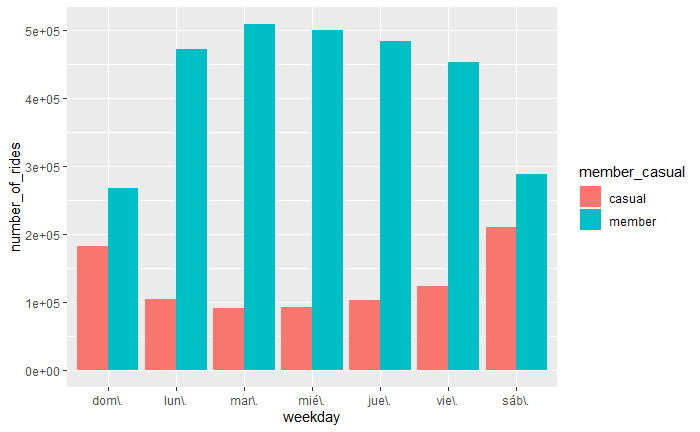

```r
all_trips_v2 %>%
  mutate(weekday = wday(started_at, label = TRUE)) %>%
  group_by(member_casual, weekday) %>%
  summarise(number_of_rides = n(), average_duration = mean(ride_length)) %>%
  arrange(member_casual, weekday) %>%
  ggplot(aes(x = weekday, y = number_of_rides, fill = member_casual)) + geom_col(position = "dodge")
```

Let’s create a visualization for average duration

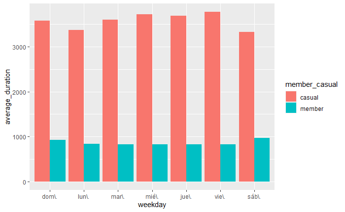

```r
all_trips_v2 %>%
  mutate(weekday = wday(started_at, label = TRUE)) %>%
  group_by(member_casual, weekday) %>%
  summarise(number_of_rides = n(), average_duration = mean(ride_length))%>%
  arrange(member_casual, weekday) %>%
  ggplot(aes(x = weekday, y = average_duration, fill = member_casual)) + geom_col(position = "dodge")
```